# Final Report

Data Science 3 with R (STAT 301-3)

Author

Qin Huang & Parth Patel (Poliecon)

## Github Repo Link

**Important**

https://github.com/STAT301-3-2023SP/final-project-poliecon.git

## Introduction

In this report, we will first introduce the dataset we are using, followed by an exploratory descriptive analysis of this data. Subsequently, I will discuss the models we have used to predict youth voting. Building on our models, I will compare the results across them, select the most effective model, and draw conclusions based on the final selected model.

## Dataset

The dataset we are using is a publicly available one entitled “The Commission on Youth Voting and Civic Knowledge Youth Post-Election Survey 2012” (Levin 2016). This study is conducted by the Center for Information and Research on Civic Learning and Engagement (CIRCLE) surveying 4,483 individuals aged 18 to 24. The study aimed to gather information about their political engagement and educational experiences. The interviews commenced the day after the 2012 presidential election and continued for six weeks afterward. The survey covered various aspects such as voter turnout, participation in elections, informed voting, voter registration, voting behavior, political and campaign knowledge, and the alignment of voting choices with personal opinions on campaign issues. In addition to these topics, the study also explored the respondents’ background experiences, their exposure to civic education in schools, families, and community settings, their current involvement with civic groups, the political climate of their state, and the implementation of education and voting laws in their state. Demographic data collected for each participant included age, race, gender, education level, employment status, and religion.

## EDA

We partitioned the dataset into an 80 percent training set and a 20 percent testing set. We initially explored the response variable (whether youths voted or not) in the training set. As depicted in the corresponding table and figure, this categorical variable is fairly balanced, with approximately 40 percent not voting and 60 percent voting. Consequently, no additional transformations are necessary for this variable.

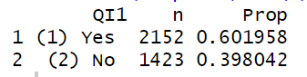

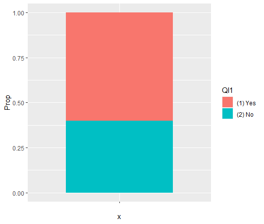

Next, I assessed the presence of missing data in our dataset. Fortunately, there are no missing values in the response variable, largely because the focus of the survey was on voting, ensuring that this particular information was captured by the interviewers. As for the predictors, the issue of missing data is relatively minor. Over half of these variables have less than 5 percent missing values, with the highest proportion being 8 percent. Consequently, we can confidently address the missing values in the predictors using imputation methods without significant impact on the integrity of our analysis.

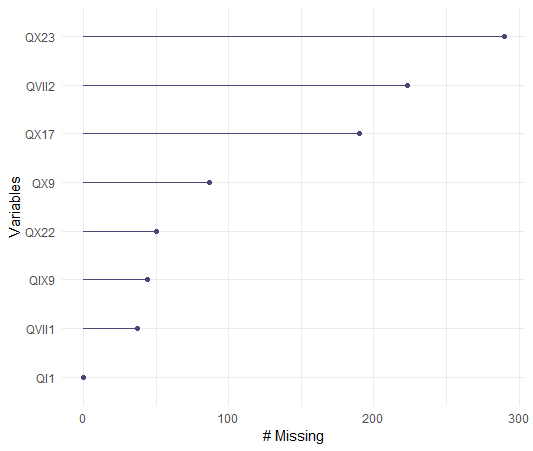

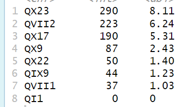

## Model Building

I use the `tidymodels` framework to tune and fit the following models. You can check respective r.files for my detailed codes for each models. I also present their results in this section (resampling with 5 fold and 3 repeats)). For null modeling, please see null_modeling.R abd null_modeling_recipe 2.R

1. elastic net
   - tune `mixture` and `penalty`
   - 1_en_tuning.R
   - 1_en_tuning_recipe 2.R

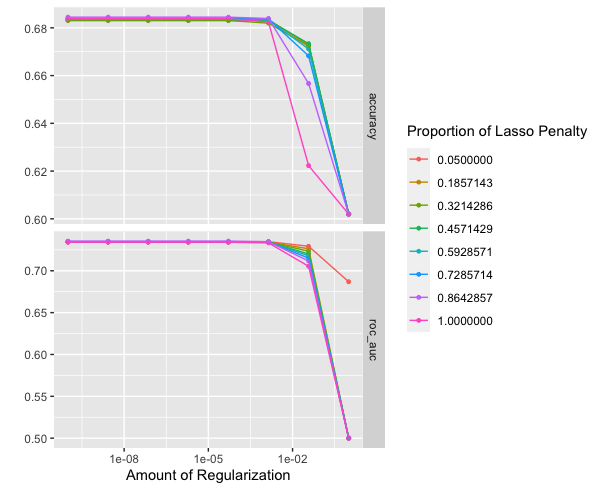

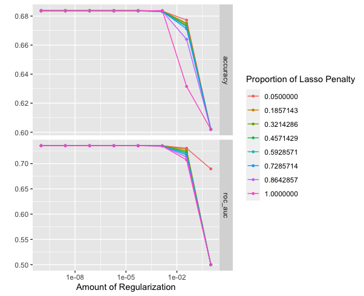

2. Nearest neighbors
   - tune number of `neighbors`
   - 1_knn_tuning.R
   - 1_knn_tuning_recipe 2.R

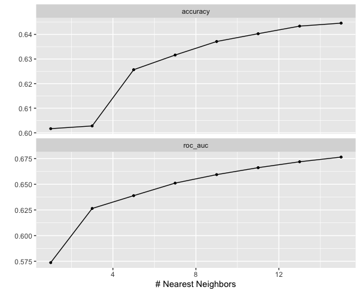

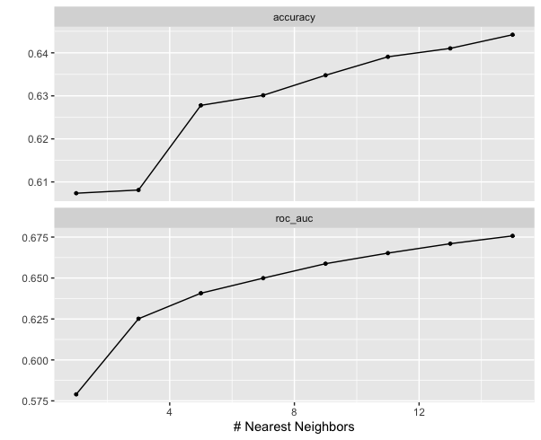

3. Random forest
   - tune `mtry` and `min_n`
   - 1_rf_tuning.R
   - 1_rf_tuning - recipe 2.R

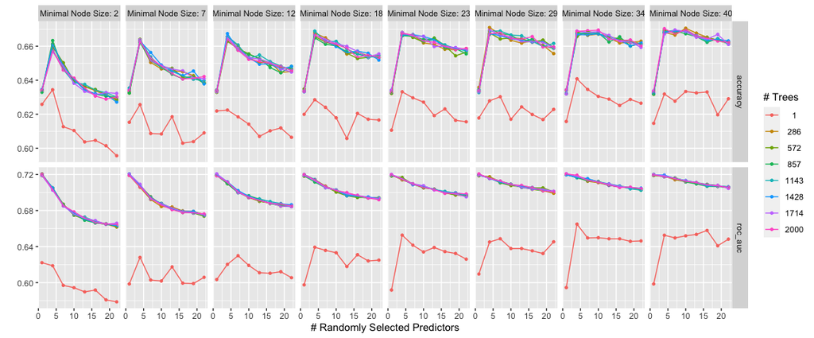

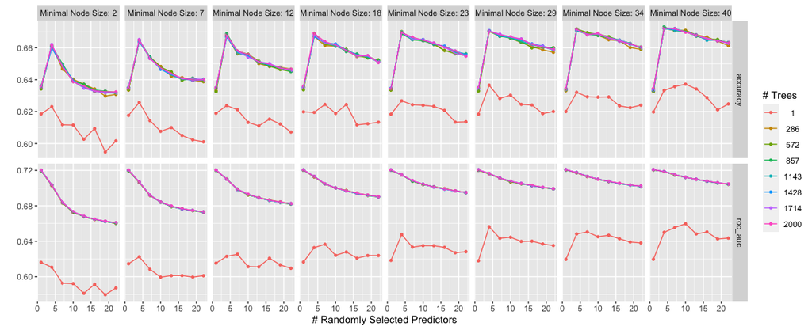

4. Boosted tree
   - tune `mtry`, `min_n`, and `learn_rate`
   - 1_bt_tuning.R
   - 1_bt_tuning - recipe 2.R

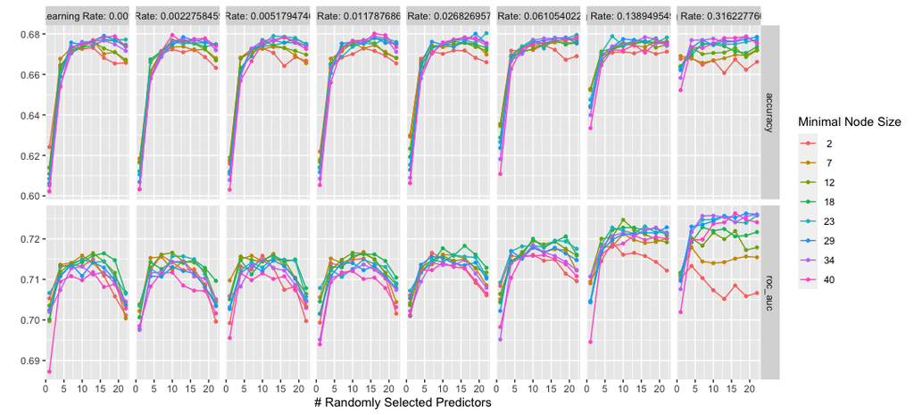

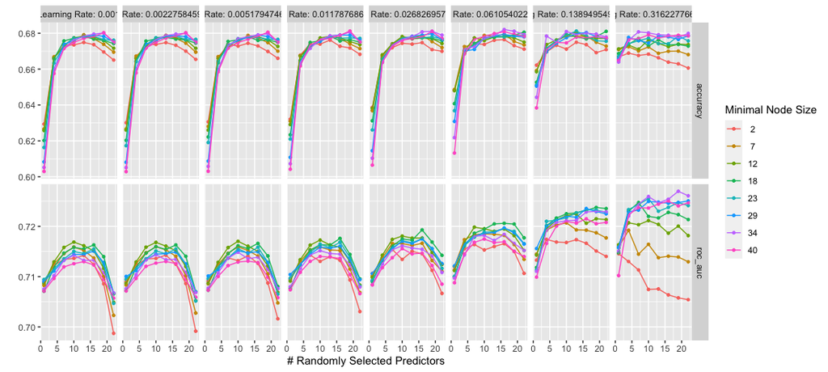

5. Support vector machine (polynomial)
   - tune `cost`, `degree`, and `scale_factor` (default values are sufficient, free to change if you want)
   - 1_SVM_poly_tuning.R
   - 1_SVM_poly_tuning - recipe 2.R

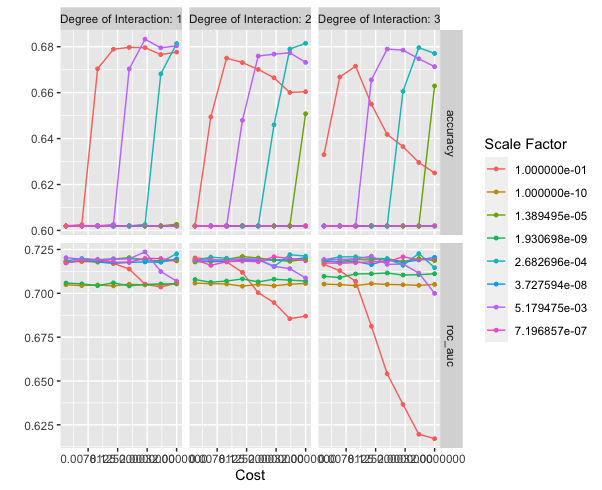

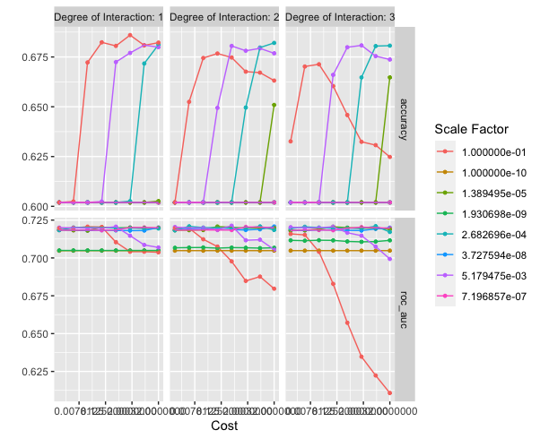

6. Support vector machine (radial basis function)
   - tune `cost` and `rbf_sigma` (default values)
   - 1_SVM_radial_tuning.R
   - 1_SVM_radial_tuning - recipe 2.R

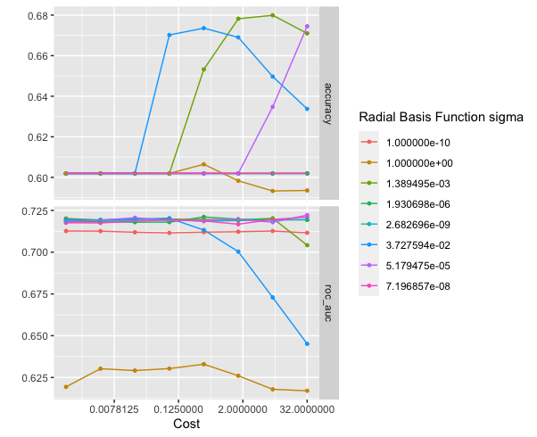

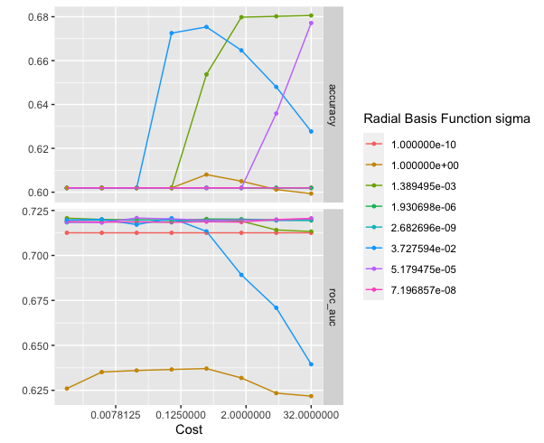

7. Single Layer Neural Network (multilayer perceptron — mlp)
   - tune `hidden_units` and `penalty` (default values)
   - 1_SLNN_MLP_tuning.R
   - 1_SLNN_MLP_tuning - recipe 2.R

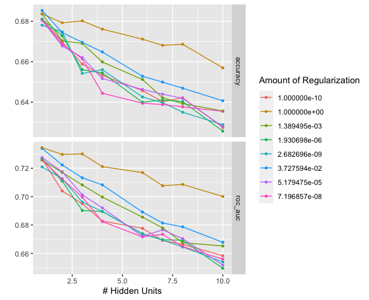

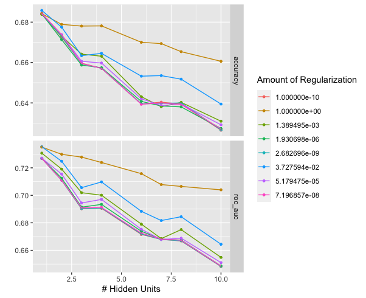

8. Multivariate adaptive regression splines (MARS)
   - tune `num_terms` (need to supply upperbound) and `prod_degree` (defualt works here)
   - 1_MARS_tuning.R
   - 1_MARS_tuning - recipe 2.R

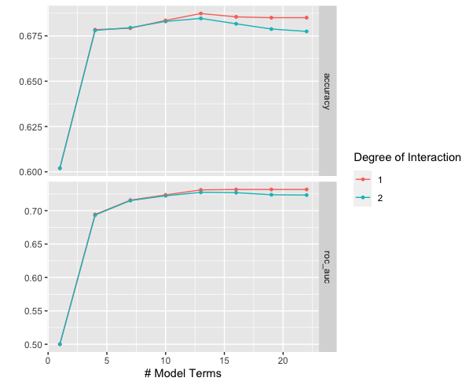

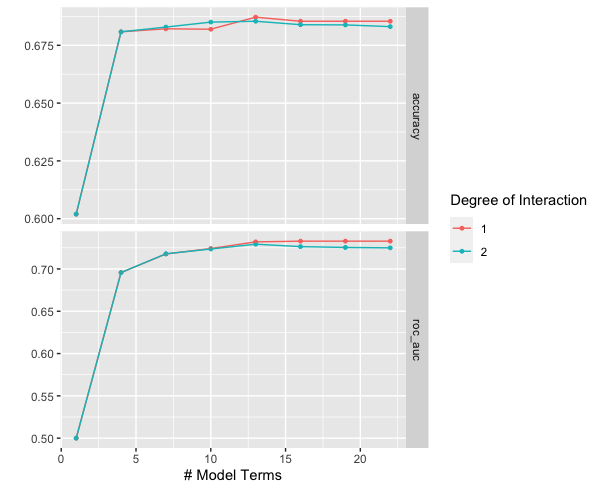

## Model Comparison

**Top Ranked Models**

Metric = ROC-AUC

| Model Type | Mean | Rank |
| --- | --- | --- |
| elastic net recipe 2 | 0.7354077 | 1 |
| single layer neural network recipe 2 | 0.7354069 | 2 |
| elastic net | 0.7353836 | 3 |
| single layer neural network | 0.7345011 | 4 |
| mars recipe 2 | 0.7328333 | 5 |
| mars | 0.7316987 | 6 |
| bt recipe 2 | 0.7269709 | 7 |
| bt | 0.7262863 | 8 |
| svm poly | 0.7236075 | 9 |
| svm rad | 0.7222078 | 10 |
| svm poly recipe 2 | 0.7212891 | 11 |
| rf | 0.7208950 | 12 |
| rf recipe 2 | 0.7208355 | 13 |
| svm rad recipe 2 | 0.7208050 | 14 |
| knn | 0.6765214 | 15 |
| knn recipe 2 | 0.6757203 | 16 |
| null recipe 2 | 0.5000000 | 17 |
| null | 0.5000000 | 18 |

**Model Runtime**

| model | runtime |
| --- | --- |
| Null Model | 10.025 |
| Null Model Recipe 2 | 16.712 |
| Random Forest | 3295.969 |
| Random Forest Recipe 2 | 5829.519 |
| Elastic Net | 19.978 |
| Elastic Net Recipe 2 | 68.795 |
| Boosted Tree | 536.383 |
| Boosted Tree Recipe 2 | 3509.499 |
| K-Nearest Neighbor | 15.154 |
| K-Nearest Neighbor Recipe 2 | 21.049 |
| SVM Radial | 223.741 |
| SVM Radial Recipe 2 | 611.107 |
| SVM Polynomial | 738.778 |
| SVM Polynomial Recipe 2 | 1853.978 |
| Single Layer Neural Network | 104.939 |
| Single Layer Neural Network Recipe 2 | 451.339 |
| MARS | 15.912 |
| MARS Recipe 2 | 26.332 |

Therefore, we applied this top-performing model to our testing set. The table included summarizes all the metrics it produces. For instance, this model achieves an accuracy of 0.7. A confusion matrix is also provided to give a more detailed view of the model’s performance.

```
# A tibble: 13 × 3
   .metric              .estimator .estimate
   <chr>                <chr>          <dbl>
 1 accuracy             binary         0.692
 2 kap                  binary         0.344
 3 sens                 binary         0.781
 4 spec                 binary         0.556
 5 ppv                  binary         0.727
 6 npv                  binary         0.627
 7 mcc                  binary         0.345
 8 j_index              binary         0.337
 9 bal_accuracy         binary         0.669
10 detection_prevalence binary         0.647
11 precision            binary         0.727
12 recall               binary         0.781
13 f_meas               binary         0.753
```

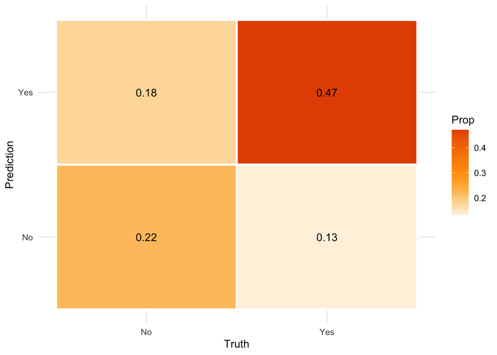

## Conclusion

From a theoretical perspective, future studies can be undertaken to identify which features are most crucial in making these predictions. This will enhance our understanding of the motivations and constraints faced by American youths when they participate in politics.

Meanwhile, future research in this field has substantial policy implications. As youth voting should be encouraged, our research will help predict in advance of elections whether particular youths are likely to vote or not. This, in turn, can guide targeted efforts to encourage those who are predicted not to vote, fostering greater political engagement among the youth.

In conclusion, our project not only contributes to a better understanding of the patterns and determinants of youth voting behavior but also provides insights that can be used to promote civic participation among this important demographic.

## References

Kam, Cindy D. and Carl L. Palmer. 2008. Reconsidering the Effects of Education on Political Participation. The Journal of Politics. 70: 612-631.

Levine, Peter. The Commission on Youth Voting and Civic Knowledge Youth Post-Election Survey 2012. Inter-university Consortium for Political and Social Research [distributor], 2016-03-24. https://doi.org/10.3886/ICPSR35012.v2

## Github Repo Link

https://github.com/STAT301-3-2023SP/final-project-poliecon.git